# PML Peer-graded Assignment

Roslen Anacleto

4/18/2017

## Load the required libraries and seed the random number generator

```r
# Suppress package startup messages
suppressPackageStartupMessages(library(caret))
suppressPackageStartupMessages(library(rattle))

# Make the results reproducible.
set.seed(315)
```

## Building the model

The source of training and testing data was http://groupware.les.inf.puc-rio.br/har. Previewing the downloaded data revealed that missing values were either represented as null strings or explicitly labeled as “NA”.

### Retrieving the data

```r
# Load the training and testing data as prescribed in the instuctions.
training <- read.csv("https://d396qusza40orc.cloudfront.net/predmachlearn/pml-training.csv",
                     header = T, na.strings = c("", "NA"))
testing <- read.csv("https://d396qusza40orc.cloudfront.net/predmachlearn/pml-testing.csv",
                    header = T, na.strings = c("", "NA"))
```

### Data quality check

Got a sense of the data structure by running commands such as:

- `dim(training)` — showed 19,622 observations and 160 variables
- `dim(testing)` — showed 20 observations and 160 variables
- `colnames(training)` — showed the names of 160 variables
- `colSums(is.na(training)) %>% sort() %>% unique()` — showed c(0, 19216)
- `colSums(is.na(testing)) %>% sort() %>% unique()` — showed c(0, 20)

The results of `colSums()` showed that there were variables with many missing values. These were removed.

```r
# Retain only those variables with no missing values; store in new variables.
tr <- training[, which(colSums(is.na(training)) == 0)]
ts <- testing[, which(colSums(is.na(testing)) == 0)]

# Exclude the first seven variables as predictors. They appear to be only descriptor variables.
tr <- tr[, -c(1:7)]
ts <- ts[, -c(1:7)]
```

### Preprocess

Do preprocessing to remove near-zero variance variables and colinearity.

```r
# Preprocess the datasets to remove near-zero variance variables and collinear
# variables.
prep <- preProcess(tr[, -53], method = c("nzv", "corr"))
tr <- predict(prep, tr)
ts <- predict(prep, ts)
# Note: No need to scale/center the data since classification trees, stochastic gradient boosting, and random forest methods will be used as prediction models.
```

### Data splitting

Split the `tr` (training) data into a training and validation subsets to estimate out-of-sample errors (primarily) and other parameters prior to doing predictions on the testing data.

```r
# Split the training data to be able to estimate the out-of-sample error. A 70-30 partition scheme as recommended in the lecture.
idx <- createDataPartition(tr$classe, p = 0.70, list = F)

# Partition the training data superset into training and validation subsets.
tr.training <- tr[idx, ]
tr.validation <- tr[-idx, ]
```

## Resampling using cross-validation

```r
# Decide on a training control strategy. Choose a relatively low number to
# prevent overfitting; use the value recommended from the lecture.
fit_control <- trainControl(method = "cv", number = 5)
```

## Training three prediction models

Compare three prediction models and choose the best one based on the training and validation accuracies.

```r
# Do classification trees modeling
fit_rpart <- train(classe ~ ., data = tr.training, method = "rpart",
                   trControl = fit_control)
print(fit_rpart)
```

```
## CART
##
## 13737 samples
##    45 predictor
##     5 classes: 'A', 'B', 'C', 'D', 'E'
##
## No pre-processing
## Resampling: Cross-Validated (5 fold)
## Summary of sample sizes: 10990, 10990, 10989, 10988, 10991
## Resampling results across tuning parameters:
##
##   cp          Accuracy   Kappa
##   0.02039467  0.5710814  0.4601323
##   0.03183806  0.4971899  0.3527018
##   0.04251856  0.4474797  0.2698838
##
## Accuracy was used to select the optimal model using  the largest value.
## The final value used for the model was cp = 0.02039467.
```

```r
# Try stochastic gradient boosting
fit_gbm <- train(classe ~ ., data = tr.training,
                 method = "gbm",
                 trControl = fit_control,
                 verbose = F)
print(fit_gbm)
```

```
## Stochastic Gradient Boosting
##
## 13737 samples
##    45 predictor
##     5 classes: 'A', 'B', 'C', 'D', 'E'
##
## No pre-processing
## Resampling: Cross-Validated (5 fold)
## Summary of sample sizes: 10989, 10990, 10990, 10990, 10989
## Resampling results across tuning parameters:
##
##   interaction.depth  n.trees  Accuracy   Kappa
##   1                   50      0.7369882  0.6664714
##   1                  100      0.8100024  0.7595839
##   1                  150      0.8470558  0.8064145
##   2                   50      0.8498223  0.8097342
##   2                  100      0.9002693  0.8738118
##   2                  150      0.9270580  0.9077078
##   3                   50      0.8936454  0.8653615
##   3                  100      0.9397976  0.9238304
##   3                  150      0.9585062  0.9475084
##
## Tuning parameter 'shrinkage' was held constant at a value of 0.1
##
## Tuning parameter 'n.minobsinnode' was held constant at a value of 10
## Accuracy was used to select the optimal model using  the largest value.
## The final values used for the model were n.trees = 150,
##  interaction.depth = 3, shrinkage = 0.1 and n.minobsinnode = 10.
```

```r
# Try random forest
fit_rf <- train(classe ~ ., data = tr.training,
                method = "rf",
                trControl = fit_control)
print(fit_rf)
```

```
## Random Forest
##
## 13737 samples
##    45 predictor
##     5 classes: 'A', 'B', 'C', 'D', 'E'
##
## No pre-processing
## Resampling: Cross-Validated (5 fold)
## Summary of sample sizes: 10989, 10991, 10990, 10989, 10989
## Resampling results across tuning parameters:
##
##   mtry  Accuracy   Kappa
##    2    0.9902454  0.9876589
##   23    0.9911919  0.9888568
##   45    0.9883525  0.9852647
##
## Accuracy was used to select the optimal model using  the largest value.
## The final value used for the model was mtry = 23.
```

Results show that classfication tree (RPART) had an accuracy of ~57%, stochastic gradient boosting (GBM) ~96%, and random forest (RF) ~99%. RF, therefore, shows the highest prediction accuracy rate on the training data.

## Plotting the predictive models

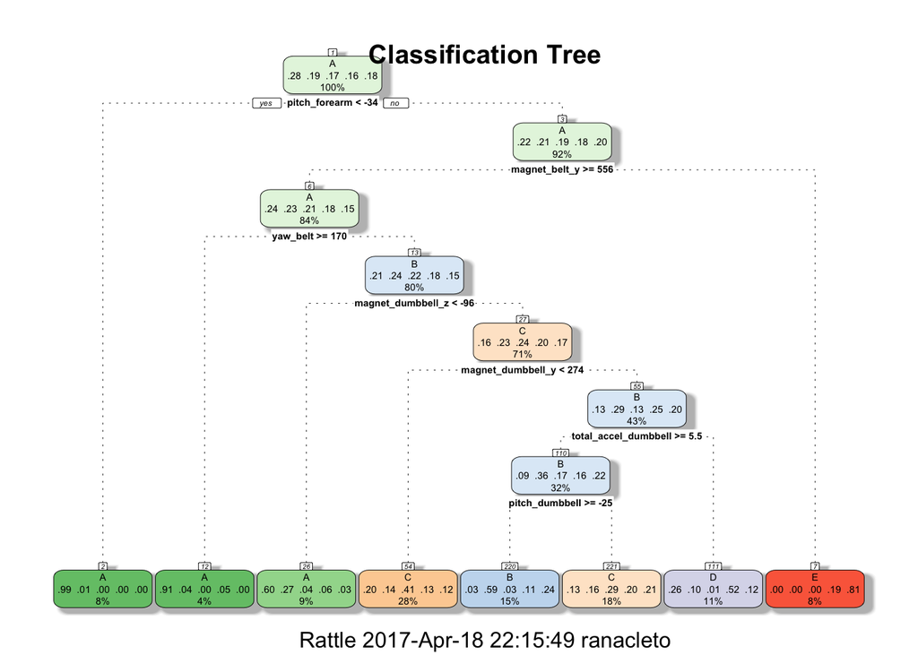

```r
# Then, plot the final models
fancyRpartPlot(fit_rpart$finalModel, main = "Classification Tree")
```

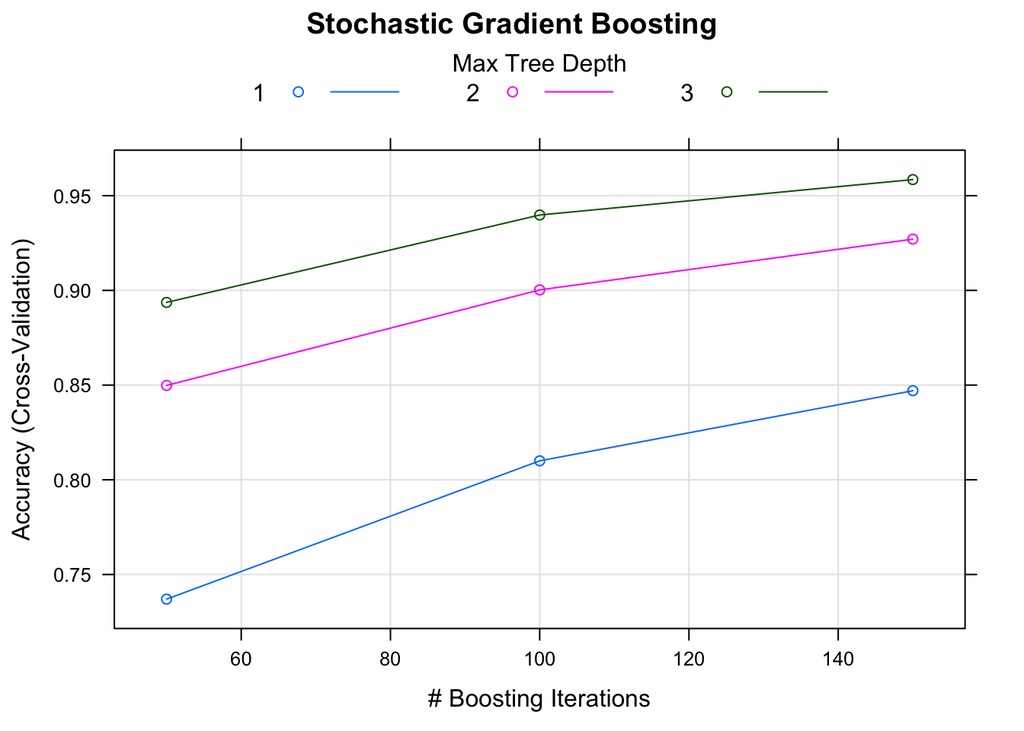

```r
plot(fit_gbm, main = "Stochastic Gradient Boosting")
```

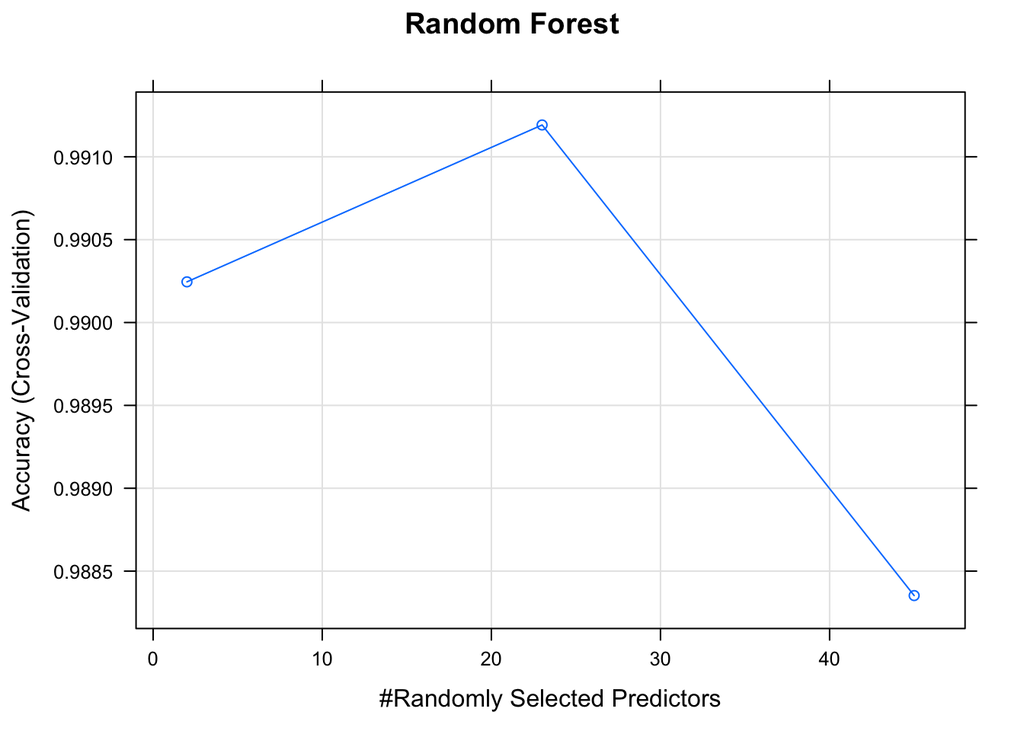

```r
plot(fit_rf, main = "Random Forest")
```

## Predictions on the validation data

```r
# Use the respective fitted models to prediction the classe values in the validation set.
predict_rpart <- predict(fit_rpart, tr.validation)
predict_gbm <- predict(fit_gbm, tr.validation)
predict_rf <- predict(fit_rf, tr.validation)

# Show confusion matrices of the three prediction models
confusionMatrix(tr.validation$classe, predict_rpart)
```

```
## Confusion Matrix and Statistics
##
##           Reference
## Prediction   A   B   C   D   E
##          A 985  29 467 192   1
##          B 179 484 403  72   1
##          C  29  18 974   5   0
##          D  41 102 433 317  71
##          E  22 225 398  85 352
##
## Overall Statistics
##
##                Accuracy : 0.5288
##                  95% CI : (0.516, 0.5416)
##     No Information Rate : 0.4545
##     P-Value [Acc > NIR] : < 2.2e-16
##
##                   Kappa : 0.4109
##  Mcnemar's Test P-Value : < 2.2e-16
##
## Statistics by Class:
##
##                      Class: A Class: B Class: C Class: D Class: E
## Sensitivity            0.7842  0.56410   0.3641  0.47243  0.82824
## Specificity            0.8512  0.86970   0.9838  0.87591  0.86630
## Pos Pred Value         0.5884  0.42493   0.9493  0.32884  0.32532
## Neg Pred Value         0.9356  0.92120   0.6499  0.92806  0.98480
## Prevalence             0.2134  0.14579   0.4545  0.11402  0.07222
## Detection Rate         0.1674  0.08224   0.1655  0.05387  0.05981
## Detection Prevalence   0.2845  0.19354   0.1743  0.16381  0.18386
## Balanced Accuracy      0.8177  0.71690   0.6740  0.67417  0.84727
```

```r
confusionMatrix(tr.validation$classe, predict_gbm)
```

```
## Confusion Matrix and Statistics
##
##           Reference
## Prediction    A    B    C    D    E
##          A 1651   16    5    1    1
##          B   47 1056   29    0    7
##          C    0   25  987   10    4
##          D    1    7   31  917    8
##          E    1   11   12   10 1048
##
## Overall Statistics
##
##                Accuracy : 0.9616
##                  95% CI : (0.9564, 0.9664)
##     No Information Rate : 0.2889
##     P-Value [Acc > NIR] : < 2.2e-16
##
##                   Kappa : 0.9514
##  Mcnemar's Test P-Value : 4.187e-06
##
## Statistics by Class:
##
##                      Class: A Class: B Class: C Class: D Class: E
## Sensitivity            0.9712   0.9471   0.9276   0.9776   0.9813
## Specificity            0.9945   0.9826   0.9919   0.9905   0.9929
## Pos Pred Value         0.9863   0.9271   0.9620   0.9512   0.9686
## Neg Pred Value         0.9884   0.9876   0.9842   0.9957   0.9958
## Prevalence             0.2889   0.1895   0.1808   0.1594   0.1815
## Detection Rate         0.2805   0.1794   0.1677   0.1558   0.1781
## Detection Prevalence   0.2845   0.1935   0.1743   0.1638   0.1839
## Balanced Accuracy      0.9828   0.9648   0.9598   0.9841   0.9871
```

```r
confusionMatrix(tr.validation$classe, predict_rf)
```

```
## Confusion Matrix and Statistics
##
##           Reference
## Prediction    A    B    C    D    E
##          A 1671    2    0    0    1
##          B    7 1127    4    0    1
##          C    0    0 1023    3    0
##          D    0    0    7  957    0
##          E    0    0    2    0 1080
##
## Overall Statistics
##
##                Accuracy : 0.9954
##                  95% CI : (0.9933, 0.997)
##     No Information Rate : 0.2851
##     P-Value [Acc > NIR] : < 2.2e-16
##
##                   Kappa : 0.9942
##  Mcnemar's Test P-Value : NA
##
## Statistics by Class:
##
##                      Class: A Class: B Class: C Class: D Class: E
## Sensitivity            0.9958   0.9982   0.9875   0.9969   0.9982
## Specificity            0.9993   0.9975   0.9994   0.9986   0.9996
## Pos Pred Value         0.9982   0.9895   0.9971   0.9927   0.9982
## Neg Pred Value         0.9983   0.9996   0.9973   0.9994   0.9996
## Prevalence             0.2851   0.1918   0.1760   0.1631   0.1839
## Detection Rate         0.2839   0.1915   0.1738   0.1626   0.1835
## Detection Prevalence   0.2845   0.1935   0.1743   0.1638   0.1839
## Balanced Accuracy      0.9976   0.9979   0.9934   0.9977   0.9989
```

## Prediction on testing data

```r
# Now, predict the test set using the random forest since it shows the highest
# accuracy.
predict(fit_rf, ts)
```

```
##  [1] B A B A A E D B A A B C B A E E A B B B
## Levels: A B C D E
```